# Seurat - Standard workflow on Tyser human gastrulation cells

Compiled: February 02, 2022

# Cell atlas of human gastrulation

- DOI: 10.1038/s41586-021-04158-y
- Data from: http://www.human-gastrula.net/

## Libraries

```r
## Libraries
suppressMessages(library(Seurat))
suppressMessages(library(ggplot2))
suppressMessages(library(gridExtra))
suppressMessages(library(dplyr))
suppressMessages(library(plotly))
suppressMessages(library(gplots))
suppressMessages(library(reshape2))
suppressMessages(library(scales))
suppressMessages(library(batchelor))
suppressMessages(library(mclust))
suppressMessages(library(gprofiler2))
# suppressMessages(library(gprofiler2))
# suppressMessages(library(SeuratWrappers)) suppressMessages(library(pheatmap))
# suppressMessages(library(topGO)) suppressMessages(library(org.Hs.eg.db))
# suppressMessages(library(destiny))
outputDir = getwd()

# library(future) plan('multiprocess', workers = 2) plan()
```

## Load data Tyser

```r
counts <- readRDS("/exports/sasc/project-287-10X_Blastocysts/data/tyser_nature_publication/raw_matrix.rds")
gene_names <- colnames(counts)

## Check if ERCCs counts exist in this table
gene_names[grep(pattern = "^ERCC\\.", x = gene_names)]
```

```
## character(0)
```

```r
## Annotation and UMAP coordinates
annot <- readRDS("/exports/sasc/project-287-10X_Blastocysts/data/tyser_nature_publication/annot_umap.rds")
head(annot)
```

```
##   X         X0         X1                        cluster_id       sub_cluster
## 1 0 12.2134980 -0.5503276 Hemogenic Endothelial Progenitors Blood Progenitors
## 2 1  2.4041495 -7.3894680                          Endoderm             DE(P)
## 3 2  6.2191260 -2.5777392                 Advanced Mesoderm Advanced Mesoderm
## 4 3  1.5289130  0.4129431                  Primitive Streak  Primitive Streak
## 5 4  9.3737220  4.1373663                      ExE Mesoderm       YS Mesoderm
## 6 5 -0.2207797 -3.6801040                    Axial Mesoderm    Axial Mesoderm
##      cell_name
## 1 SS.sc7785290
## 2 SS.sc7786612
## 3 SS.sc7786605
## 4 SS.sc7785737
## 5 SS.sc7785398
## 6 SS.sc7788091
```

```r
## Add the cell IDs as rownames
rownames(counts) <- annot$cell_name
counts <- t(counts)

rownames(annot) <- annot$cell_name
## Extra annotation
extra_annot <- read.delim("/exports/sasc/project-287-10X_Blastocysts/data/tyser_nature_publication/E-MTAB-9388.sdrf.txt")
extra_annot <- extra_annot %>%
    filter(grepl("1.fastq.gz", Comment.FASTQ_URI.))
extra_annot <- extra_annot %>%
    select(c(Source.Name, Characteristics.sampling.site., Characteristics.inferred.cell.type...authors.labels.,
        Characteristics.inferred.cell.type...ontology.labels.))
extra_annot$Source.Name <- gsub(pattern = "_", replacement = ".", x = extra_annot$Source.Name)
annot <- inner_join(x = extra_annot, y = annot, by = c(Source.Name = "cell_name"))
annot <- annot %>%
    select(-c(X, X0, X1))
row.names(annot) <- annot$Source.Name
```

## Create Seurat object

- Add metadata

```r
seurat_object <- CreateSeuratObject(counts = counts)
seurat_object <- AddMetaData(object = seurat_object, metadata = annot)
seurat_object
```

```
## An object of class Seurat
## 57490 features across 1195 samples within 1 assay
## Active assay: RNA (57490 features, 0 variable features)
```

```r
head(seurat_object)
```

```
##                 orig.ident nCount_RNA nFeature_RNA  Source.Name
## SS.sc7785290 SeuratProject     377152         4922 SS.sc7785290
## SS.sc7786612 SeuratProject     259889         6942 SS.sc7786612
## SS.sc7786605 SeuratProject     437911         6140 SS.sc7786605
## SS.sc7785737 SeuratProject     322352         3800 SS.sc7785737
## SS.sc7785398 SeuratProject     394319         2964 SS.sc7785398
## SS.sc7788091 SeuratProject     298218         5030 SS.sc7788091
## SS.sc7785785 SeuratProject     362622         4259 SS.sc7785785
## SS.sc7785959 SeuratProject     454115         3842 SS.sc7785959
## SS.sc7785611 SeuratProject     604384         5249 SS.sc7785611
## SS.sc7786585 SeuratProject     465547         3312 SS.sc7786585
##              Characteristics.sampling.site.
## SS.sc7785290                       yolk sac
## SS.sc7786612                        rostral
## SS.sc7786605                        rostral
## SS.sc7785737                         caudal
## SS.sc7785398                       yolk sac
## SS.sc7788091                         caudal
## SS.sc7785785                         caudal
## SS.sc7785959                         caudal
## SS.sc7785611                        rostral
## SS.sc7786585                        rostral
##              Characteristics.inferred.cell.type...authors.labels.
## SS.sc7785290                     hemogenic endothelial progenitor
## SS.sc7786612                                      endodermal cell
## SS.sc7786605                                    advanced mesoderm
## SS.sc7785737                                     primitive streak
## SS.sc7785398                                    yolk sac mesoderm
## SS.sc7788091                                       axial mesoderm
## SS.sc7785785                                          erythrocyte
## SS.sc7785959                                    advanced mesoderm
## SS.sc7785611                                      endodermal cell
## SS.sc7786585                                    emergent mesoderm
##              Characteristics.inferred.cell.type...ontology.labels.
## SS.sc7785290                                         hemangioblast
## SS.sc7786612                                       endodermal cell
## SS.sc7786605                                         mesoderm cell
## SS.sc7785737                                 primitive streak cell
## SS.sc7785398                                mesenchyme of yolk sac
## SS.sc7788091                                 chordamesodermal cell
## SS.sc7785785                                           erythrocyte
## SS.sc7785959                                         mesoderm cell
## SS.sc7785611                                       endodermal cell
## SS.sc7786585                                       mesodermal cell
##                                     cluster_id       sub_cluster
## SS.sc7785290 Hemogenic Endothelial Progenitors Blood Progenitors
## SS.sc7786612                          Endoderm             DE(P)
## SS.sc7786605                 Advanced Mesoderm Advanced Mesoderm
## SS.sc7785737                  Primitive Streak  Primitive Streak
## SS.sc7785398                      ExE Mesoderm       YS Mesoderm
## SS.sc7788091                    Axial Mesoderm    Axial Mesoderm
## SS.sc7785785                     Erythroblasts     Erythroblasts
## SS.sc7785959                 Advanced Mesoderm Advanced Mesoderm
## SS.sc7785611                          Endoderm       YS Endoderm
## SS.sc7786585                 Emergent Mesoderm Emergent Mesoderm
```

```r
# seurat_object$clusterid <- umap$cluster_id seurat_object$subcluster <-
# umap$sub_cluster seurat_object$spacial <- metadata$origin
```

## QC

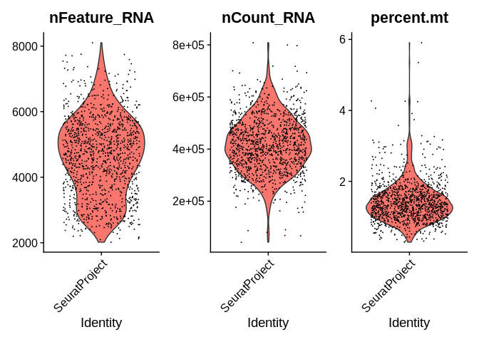

```r
seurat_object[["percent.mt"]] <- PercentageFeatureSet(seurat_object, pattern = "^MT.")
VlnPlot(seurat_object, features = c("nFeature_RNA", "nCount_RNA", "percent.mt"),
    ncol = 3)
```

```r
seurat_object <- subset(seurat_object, subset = nFeature_RNA > 4000)
seurat_object
```

```
## An object of class Seurat
## 57490 features across 838 samples within 1 assay
## Active assay: RNA (57490 features, 0 variable features)
```

## Dissociation genes on normalizeds data

- Calculate the expression of dissociation genes as a fraction of total expression (for details see 10.1038/nmeth.4437)
- We calculate it on normalized counts

```r
seurat_object <- NormalizeData(seurat_object, normalization.method = "LogNormalize",
    scale.factor = 1e+06)

genesChrom <- c("Actg1__chr11", "Ankrd1__chr19", "Arid5a__chr1", "Atf3__chr1", "Atf4__chr15",
    "Bag3__chr7", "Bhlhe40__chr6", "Brd2__chr17", "Btg1__chr10", "Btg2__chr1", "Ccnl1__chr3",
    "Ccrn4l__chr3", "Cebpb__chr2", "Cebpd__chr16", "Cebpg__chr7", "Csrnp1__chr9",
    "Cxcl1__chr5", "Cyr61__chr3", "Dcn__chr10", "Ddx3x__chrX", "Ddx5__chr11", "Des__chr1",
    "Dnaja1__chr4", "Dnajb1__chr8", "Dnajb4__chr3", "Dusp1__chr17", "Dusp8__chr7",
    "Egr1__chr18", "Egr2__chr10", "Eif1__chr11", "Eif5__chr12", "Erf__chr7", "Errfi1__chr4",
    "Fam132b__chr1", "Fos__chr12", "Fosb__chr7", "Fosl2__chr5", "Gadd45a__chr6",
    "Gcc1__chr6", "Gem__chr4", "H3f3b__chr11", "Hipk3__chr2", "Hsp90aa1__chr12",
    "Hsp90ab1__chr17", "Hspa1a__chr17", "Hspa1b__chr17", "Hspa5__chr2", "Hspa8__chr9",
    "Hspb1__chr5", "Hsph1__chr5", "Id3__chr4", "Idi1__chr13", "Ier2__chr8", "Ier3__chr17",
    "Ifrd1__chr12", "Il6__chr5", "Irf1__chr11", "Irf8__chr8", "Itpkc__chr7", "Jun__chr4",
    "Junb__chr8", "Jund__chr8", "Klf2__chr8", "Klf4__chr4", "Klf6__chr13", "Klf9__chr19",
    "Litaf__chr16", "Lmna__chr3", "Maff__chr15", "Mafk__chr5", "Mcl1__chr3", "Midn__chr10",
    "Mir22hg__chr11", "Mt1__chr8", "Mt2__chr8", "Myadm__chr7", "Myc__chr15", "Myd88__chr9",
    "Nckap5l__chr15", "Ncoa7__chr10", "Nfkbia__chr12", "Nfkbiz__chr16", "Nop58__chr1",
    "Nppc__chr1", "Nr4a1__chr15", "Odc1__chr12", "Osgin1__chr8", "Oxnad1__chr14",
    "Pcf11__chr7", "Pde4b__chr4", "Per1__chr11", "Phlda1__chr10", "Pnp__chr14", "Pnrc1__chr4",
    "Ppp1cc__chr5", "Ppp1r15a__chr7", "Pxdc1__chr13", "Rap1b__chr10", "Rassf1__chr9",
    "Rhob__chr12", "Rhoh__chr5", "Ripk1__chr13", "Sat1__chrX", "Sbno2__chr10", "Sdc4__chr2",
    "Serpine1__chr5", "Skil__chr3", "Slc10a6__chr5", "Slc38a2__chr15", "Slc41a1__chr1",
    "Socs3__chr11", "Sqstm1__chr11", "Srf__chr17", "Srsf5__chr12", "Srsf7__chr17",
    "Stat3__chr11", "Tagln2__chr1", "Tiparp__chr3", "Tnfaip3__chr10", "Tnfaip6__chr2",
    "Tpm3__chr3", "Tppp3__chr8", "Tra2a__chr6", "Tra2b__chr16", "Trib1__chr15", "Tubb4b__chr2",
    "Tubb6__chr18", "Ubc__chr5", "Usp2__chr9", "Wac__chr18", "Zc3h12a__chr4", "Zfand5__chr19",
    "Zfp36__chr7", "Zfp36l1__chr12", "Zfp36l2__chr17", "Zyx__chr6", "Gadd45g__chr13",
    "Hspe1__chr1", "Ier5__chr1", "Kcne4__chr1")

genes <- sapply(genesChrom, function(x) {
    toupper(strsplit(x, "__")[[1]][1])
})

Data <- as.data.frame(as.matrix(GetAssayData(object = seurat_object)))
cat("All genes:\n")
```

```
## All genes:
```

```r
print(unname(genes))
```

```
##   [1] "ACTG1"    "ANKRD1"   "ARID5A"   "ATF3"     "ATF4"     "BAG3"
##   [7] "BHLHE40"  "BRD2"     "BTG1"     "BTG2"     "CCNL1"    "CCRN4L"
##  [13] "CEBPB"    "CEBPD"    "CEBPG"    "CSRNP1"   "CXCL1"    "CYR61"
##  [19] "DCN"      "DDX3X"    "DDX5"     "DES"      "DNAJA1"   "DNAJB1"
##  [25] "DNAJB4"   "DUSP1"    "DUSP8"    "EGR1"     "EGR2"     "EIF1"
##  [31] "EIF5"     "ERF"      "ERRFI1"   "FAM132B"  "FOS"      "FOSB"
##  [37] "FOSL2"    "GADD45A"  "GCC1"     "GEM"      "H3F3B"    "HIPK3"
##  [43] "HSP90AA1" "HSP90AB1" "HSPA1A"   "HSPA1B"   "HSPA5"    "HSPA8"
##  [49] "HSPB1"    "HSPH1"    "ID3"      "IDI1"     "IER2"     "IER3"
##  [55] "IFRD1"    "IL6"      "IRF1"     "IRF8"     "ITPKC"    "JUN"
##  [61] "JUNB"     "JUND"     "KLF2"     "KLF4"     "KLF6"     "KLF9"
##  [67] "LITAF"    "LMNA"     "MAFF"     "MAFK"     "MCL1"     "MIDN"
##  [73] "MIR22HG"  "MT1"      "MT2"      "MYADM"    "MYC"      "MYD88"
##  [79] "NCKAP5L"  "NCOA7"    "NFKBIA"   "NFKBIZ"   "NOP58"    "NPPC"
##  [85] "NR4A1"    "ODC1"     "OSGIN1"   "OXNAD1"   "PCF11"    "PDE4B"
##  [91] "PER1"     "PHLDA1"   "PNP"      "PNRC1"    "PPP1CC"   "PPP1R15A"
##  [97] "PXDC1"    "RAP1B"    "RASSF1"   "RHOB"     "RHOH"     "RIPK1"
## [103] "SAT1"     "SBNO2"    "SDC4"     "SERPINE1" "SKIL"     "SLC10A6"
## [109] "SLC38A2"  "SLC41A1"  "SOCS3"    "SQSTM1"   "SRF"      "SRSF5"
## [115] "SRSF7"    "STAT3"    "TAGLN2"   "TIPARP"   "TNFAIP3"  "TNFAIP6"
## [121] "TPM3"     "TPPP3"    "TRA2A"    "TRA2B"    "TRIB1"    "TUBB4B"
## [127] "TUBB6"    "UBC"      "USP2"     "WAC"      "ZC3H12A"  "ZFAND5"
## [133] "ZFP36"    "ZFP36L1"  "ZFP36L2"  "ZYX"      "GADD45G"  "HSPE1"
## [139] "IER5"     "KCNE4"
```

```r
write.table(genes, paste0(outputDir, "/mouseDissocGenes.tsv"), sep = "\t", quote = FALSE,
    row.names = FALSE)

## Remove mouse only genes and put the corresponding human
genes <- genes[!genes %in% c("CCRN4L", "MT1", "MT2")]
genes <- c(genes, "NOCT", "MT1A", "MT2A")
cat("Genes from mouse we miss in human:\n")
```

```
## Genes from mouse we miss in human:
```

```r
unname(genes[!genes %in% row.names(Data)])
```

```
## [1] "FAM132B"
```

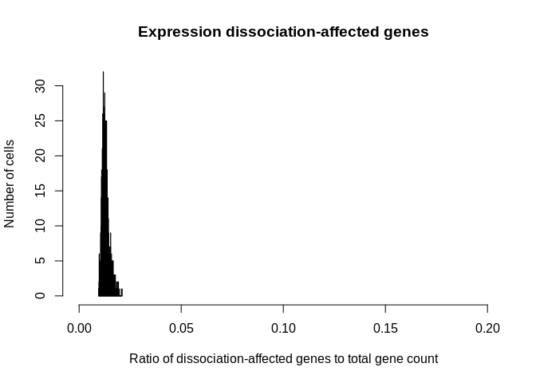

```r
## Calculate the percentage of UMIs maping on dissociation genes
totalSum <- Matrix::colSums(GetAssayData(object = seurat_object))
selection <- Data[genes, ]
selection[is.na(selection)] <- 0
dissociationSums <- colSums(selection)
countSums <- merge(totalSum, dissociationSums, by = "row.names", all = TRUE, sort = FALSE)
rownames(countSums) <- countSums$Row.names
countSums <- countSums[-1]
colnames(countSums) <- c("totalCount", "dissociationCounts")
countSums$percentage <- countSums$dissociationCounts/countSums$totalCount
## Save in meta.data of object
seurat_object[["percent.dissoc"]] <- countSums$percentage

## Draw histogram for all samples
percentages <- seurat_object$percent.dissoc
hist(percentages, breaks = 100, col = "lightgrey", main = paste("Expression dissociation-affected genes"),
    xlab = "Ratio of dissociation-affected genes to total gene count", ylab = "Number of cells",
    xlim = c(0, 0.2))
```

```r
## Remove object to free up mem
rm(Data)
```

## Highly Variable Features

```
## When using repel, set xnudge and ynudge to 0 for optimal results
```

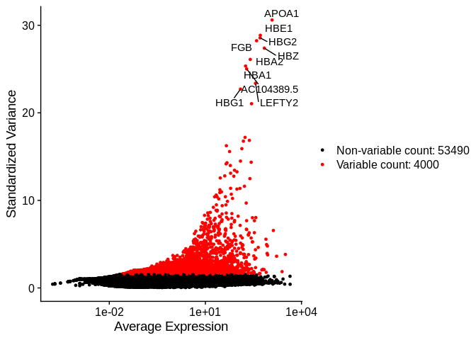

```r
seurat_object <- FindVariableFeatures(seurat_object, selection.method = "vst", nfeatures = 4000)

# Identify the 10 most highly variable genes
top10 <- head(VariableFeatures(seurat_object), 10)
plot1 <- VariableFeaturePlot(seurat_object)
LabelPoints(plot = plot1, points = top10, repel = TRUE)
```

## Scale data

```r
all.genes <- rownames(seurat_object)
seurat_object <- ScaleData(seurat_object, features = all.genes)
```

## PCA

```r
seurat_object <- RunPCA(seurat_object, features = VariableFeatures(object = seurat_object))
```

```
## PC_ 1
## Positive:  LAPTM5, FCER1G, GMFG, MEF2C, ARHGDIB, FERMT3, PLEK, FYB1, TYROBP, LST1
##     ICAM2, HCST, RGS10, LCP2, S100A4, SYK, BIN2, MMRN1, LYL1, RAC2
##     LRMP, FLI1, VSIR, SRGN, HCLS1, CSF1R, INKA1, MFNG, PECAM1, PARVG
## Negative:  KRT19, ID3, APOE, CRABP2, CSRP2, CTSV, CLDN6, KRT8, AC106864.1, H2AFY2
##     MYH10, UCHL1, ID1, CA14, GPC3, TUBB2B, CRABP1, TMEM54, CADM1, EPCAM
##     POU5F1, DSP, VCAN, ID2, SPARC, CNTNAP2, ROR1, ANXA2, RARRES2, TDGF1
## PC_ 2
## Positive:  PMAIP1, POU5F1, CRABP1, SFRP2, CKS2, GPC4, PIMREG, RRM2, CCNB2, AC106864.1
##     UCHL1, GAL, TDGF1, DLGAP5, SEPHS1, NUSAP1, ESRG, CLDN10, TBXT, AURKB
##     NTS, MLF1, TOP2A, CTSC, UBE2C, NDC80, CDK1, MCM4, CCNA2, MAP1B
## Negative:  VTN, APOA1, PITX2, FGB, S100A10, TTR, DPP4, APOB, F2, LGALS2
##     PLA2G12B, ANXA3, SMLR1, GSTA2, MTTP, CDKN1C, FGA, PDZK1, AMN, DDC
##     RBP4, CUBN, APOA2, AKR1D1, SOAT2, AFP, FABP1, HMGCS2, DPYS, SLC39A5
## PC_ 3
## Positive:  EPCAM, APOA2, FGB, F2, PDZK1, LGALS2, RBP4, SMLR1, FGA, APOB
##     MTTP, APOM, PLA2G12B, TTR, MUSTN1, AKR1D1, SOAT2, AFP, GSTA2, FABP1
##     DPYS, RNF128, CUBN, SERPINA1, DDC, SLC39A5, HMGCS2, CRYM, CA4, APOA1
## Negative:  LUM, COL3A1, HAND1, POSTN, ACTC1, DCN, COLEC12, IGF2, H19, HAPLN1
##     LINC02381, AQP1, SNAI2, SVEP1, ANXA1, NID2, COL1A1, EPHA7, COL6A3, COL5A2
##     MMP28, PTN, CDH11, TMEM88, ARID5B, PMP22, FIBIN, VIM, DNAH2, DDR2
## PC_ 4
## Positive:  MT1X, RRM2, MT1G, NUSAP1, MT1H, ACAT2, KPNA2, MT2A, PIMREG, TK1
##     CCNA2, CDKN3, AURKB, TOP2A, CCNB2, MT1E, DLGAP5, NDC80, CDC20, UBE2C
##     HMBS, KIF22, CKS2, CDCA3, MYBL2, SEPHS1, HIST1H4C, KIF20A, APOC1, HIST3H2A
## Negative:  C20orf85, C1orf194, CFAP126, TEKT1, CAPSL, CFAP52, DRC1, FAM183A, ZMYND10, C9orf24
##     C11orf88, DAW1, TPPP3, SPAG6, CCNO, TEX26, MAP3K19, PKD1L1, CFAP206, CHRD
##     CFAP77, AKAP14, CFAP44, MORN5, DNAH12, C6orf118, RSPH4A, ARMC3, LRRC18, C7orf57
## PC_ 5
## Positive:  IRF8, AGR2, C1QC, TIMD4, LSP1, CCL3, CD86, C1QA, CYBB, IL10RA
##     CD1C, C1QB, SIGLEC14, BLNK, S100B, IPCEF1, HAVCR2, GPR34, CCL4, MILR1
##     PTPRC, LRRC25, RAB7B, IGSF6, PLD4, MMP9, ADORA3, MRC1, CD53, CD14
## Negative:  GATA1, TUBB1, HEMGN, RHAG, MPIG6B, LY6G6F, ITGB3, GP1BA, GFI1B, MFSD2B
##     PTCRA, TSPAN32, NXF3, HBD, CMTM5, HBE1, LAT, HBA1, ALOX12, C2orf88
##     PF4, RHD, CLEC1B, AC104389.5, SELP, THBS1, HBG1, HBG2, RHCE, GP1BB
```

```r
# Examine and visualize PCA results a few different ways
print(seurat_object[["pca"]], dims = 1:5, nfeatures = 5)
```

```
## PC_ 1
## Positive:  LAPTM5, FCER1G, GMFG, MEF2C, ARHGDIB
## Negative:  KRT19, ID3, APOE, CRABP2, CSRP2
## PC_ 2
## Positive:  PMAIP1, POU5F1, CRABP1, SFRP2, CKS2
## Negative:  VTN, APOA1, PITX2, FGB, S100A10
## PC_ 3
## Positive:  EPCAM, APOA2, FGB, F2, PDZK1
## Negative:  LUM, COL3A1, HAND1, POSTN, ACTC1
## PC_ 4
## Positive:  MT1X, RRM2, MT1G, NUSAP1, MT1H
## Negative:  C20orf85, C1orf194, CFAP126, TEKT1, CAPSL
## PC_ 5
## Positive:  IRF8, AGR2, C1QC, TIMD4, LSP1
## Negative:  GATA1, TUBB1, HEMGN, RHAG, MPIG6B
```

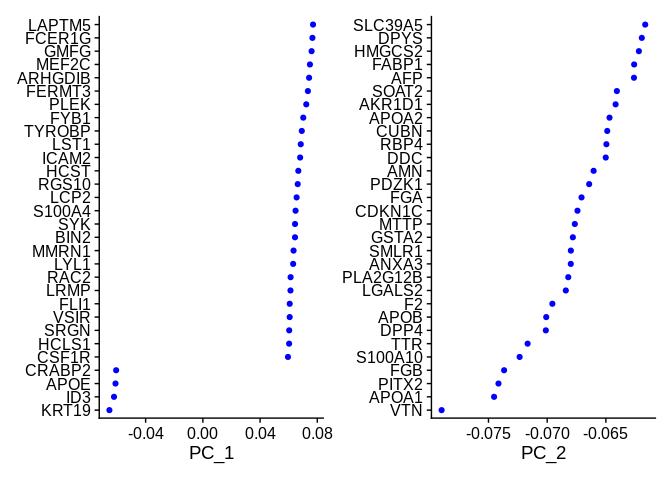

```r
VizDimLoadings(seurat_object, dims = 1:2, reduction = "pca")
```

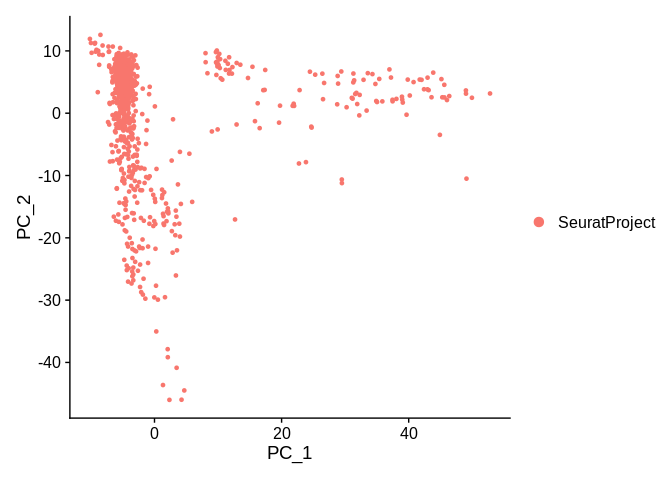

```r
DimPlot(seurat_object, reduction = "pca")
```

## Elbow plot

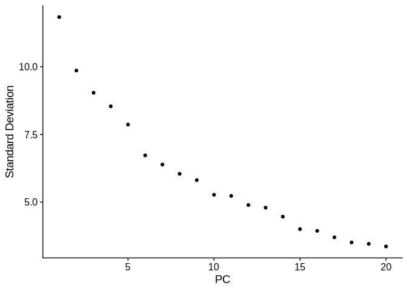

```r
ElbowPlot(seurat_object)
```

## Percent of explained variance per PC

- The variance explained is calculated following:
  - https://github.com/satijalab/seurat/issues/982
  - https://github.com/satijalab/seurat/pull/1335

```r
total_variance <- seurat_object@reductions$pca@misc$total.variance
eigValues <- (seurat_object@reductions$pca@stdev)^2
varExplained <- eigValues/total_variance
names(varExplained) <- colnames(seurat_object@reductions$pca)
varExplained
```

```
##        PC_1        PC_2        PC_3        PC_4        PC_5        PC_6
## 0.040135196 0.027863754 0.023426213 0.020895985 0.017730426 0.012966381
##        PC_7        PC_8        PC_9       PC_10       PC_11       PC_12
## 0.011700523 0.010479640 0.009683488 0.007964161 0.007845513 0.006865644
##       PC_13       PC_14       PC_15       PC_16       PC_17       PC_18
## 0.006595892 0.005714511 0.004594810 0.004449843 0.003925512 0.003537021
##       PC_19       PC_20       PC_21       PC_22       PC_23       PC_24
## 0.003432263 0.003244862 0.003166770 0.003135540 0.003011535 0.002959084
##       PC_25       PC_26       PC_27       PC_28       PC_29       PC_30
## 0.002779074 0.002750125 0.002701694 0.002655461 0.002607236 0.002577751
##       PC_31       PC_32       PC_33       PC_34       PC_35       PC_36
## 0.002557870 0.002518719 0.002470396 0.002455507 0.002428202 0.002415250
##       PC_37       PC_38       PC_39       PC_40       PC_41       PC_42
## 0.002400423 0.002391419 0.002358750 0.002349553 0.002327505 0.002325775
##       PC_43       PC_44       PC_45       PC_46       PC_47       PC_48
## 0.002287536 0.002282389 0.002272680 0.002257192 0.002241187 0.002235778
##       PC_49       PC_50
## 0.002228201 0.002222681
```

```r
cumsum(varExplained)
```

```
##       PC_1       PC_2       PC_3       PC_4       PC_5       PC_6       PC_7
## 0.04013520 0.06799895 0.09142516 0.11232115 0.13005157 0.14301795 0.15471848
##       PC_8       PC_9      PC_10      PC_11      PC_12      PC_13      PC_14
## 0.16519812 0.17488161 0.18284577 0.19069128 0.19755692 0.20415282 0.20986733
##      PC_15      PC_16      PC_17      PC_18      PC_19      PC_20      PC_21
## 0.21446214 0.21891198 0.22283749 0.22637451 0.22980678 0.23305164 0.23621841
##      PC_22      PC_23      PC_24      PC_25      PC_26      PC_27      PC_28
## 0.23935395 0.24236548 0.24532457 0.24810364 0.25085377 0.25355546 0.25621092
##      PC_29      PC_30      PC_31      PC_32      PC_33      PC_34      PC_35
## 0.25881816 0.26139591 0.26395378 0.26647250 0.26894289 0.27139840 0.27382660
##      PC_36      PC_37      PC_38      PC_39      PC_40      PC_41      PC_42
## 0.27624185 0.27864227 0.28103369 0.28339244 0.28574200 0.28806950 0.29039528
##      PC_43      PC_44      PC_45      PC_46      PC_47      PC_48      PC_49
## 0.29268281 0.29496520 0.29723788 0.29949507 0.30173626 0.30397204 0.30620024
##      PC_50
## 0.30842292
```

## Clustering with resulution = 1

- Switch to Leiden algorithm, (algorithm = 4)
- https://www.rdocumentation.org/packages/Seurat/versions/4.0.1/topics/FindClusters

```r
seurat_object <- FindNeighbors(seurat_object, reduction = "pca", dims = 1:30)
seurat_object <- FindClusters(seurat_object, resolution = 1, algorithm = 4)  # ,
# future.seed=TRUE)
```

## Adjusted Rand Index

- Compare Seurat clustering with clustering provided by authors
- ARI is 0 in case of random partition of clusters and 1 in case of perfect agreement

```r
adjustedRandIndex(seurat_object$RNA_snn_res.1, seurat_object$cluster_id)
```

```
## [1] 0.6696562
```

```r
adjustedRandIndex(seurat_object$RNA_snn_res.1, seurat_object$sub_cluster)
```

```
## [1] 0.6152745
```

## UMAP

- Clustering from Seurat and clustering as indicated by authors

```r
seurat_object <- RunUMAP(seurat_object, dims = 1:30)
```

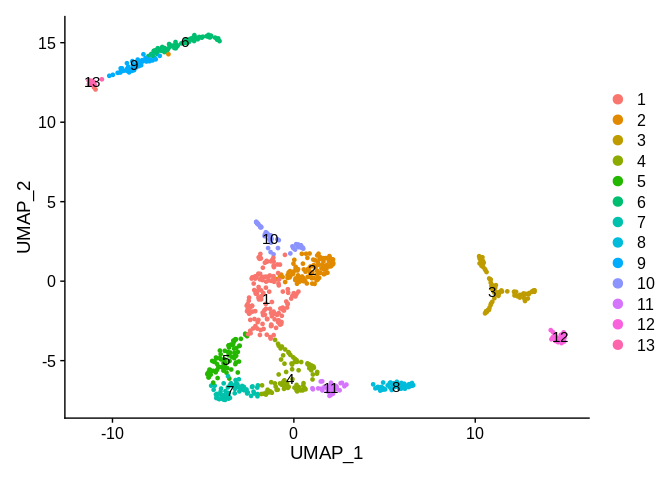

```r
DimPlot(seurat_object, reduction = "umap", label = TRUE)
```

```r
ggsave("umap.pdf")
```

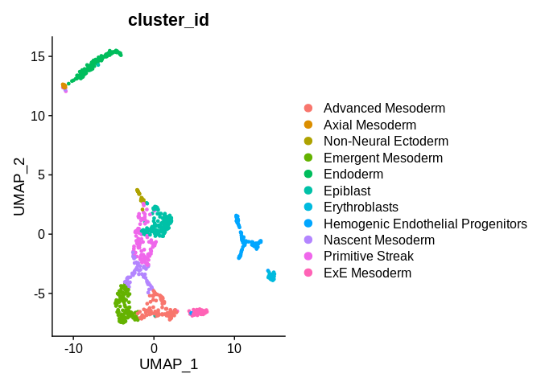

```r
DimPlot(seurat_object, reduction = "umap", group.by = "cluster_id")
```

```r
ggsave("umap_cluster_ids.pdf")
```

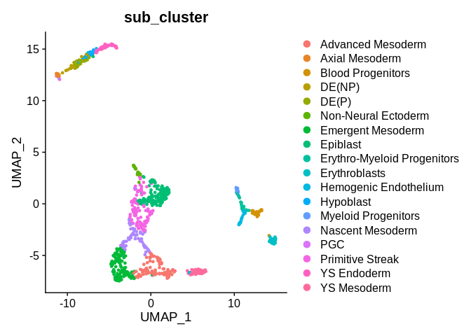

```r
DimPlot(seurat_object, reduction = "umap", group.by = "sub_cluster")
```

```r
ggsave("umap_fine_clustering.pdf")
```

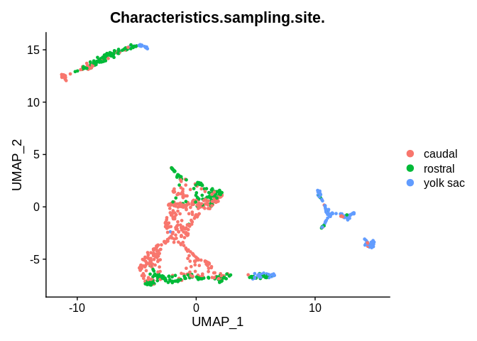

```r
DimPlot(seurat_object, reduction = "umap", group.by = "Characteristics.sampling.site.")
```

```r
ggsave("umap_spacial.pdf")
```

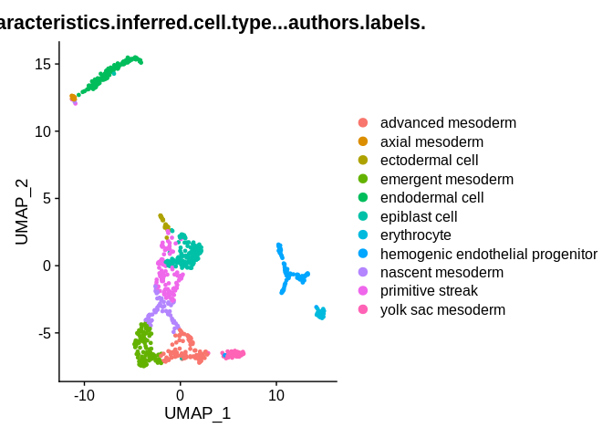

```r
DimPlot(seurat_object, reduction = "umap", group.by = "Characteristics.inferred.cell.type...authors.labels.")
```

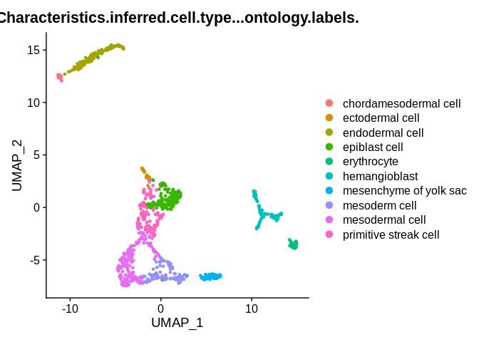

```r
DimPlot(seurat_object, reduction = "umap", group.by = "Characteristics.inferred.cell.type...ontology.labels.")
```

```r
saveRDS(seurat_object, "/exports/sasc/project-287-10X_Blastocysts/analysis/tyser_gastrulation/tyser.rds")
```

## Finding differentially expressed features

Seurat can help you find markers that define clusters via differential expression. With settings used below, it identifies positive only markers of a single cluster (specified in ident.1), compared to all other cells. FindAllMarkers() automates this process for all clusters, but you can also test groups of clusters vs. each other, or against all cells.

The min.pct argument requires a feature to be detected at a minimum percentage in either of the two groups of cells, and the thresh.test argument requires a feature to be differentially expressed (on average) by some amount between the two groups. You can set both of these to 0, but with a dramatic increase in time - since this will test a large number of features that are unlikely to be highly discriminatory. As another option to speed up these computations, max.cells.per.ident can be set. This will downsample each identity class to have no more cells than whatever this is set to. While there is generally going to be a loss in power, the speed increases can be significant and the most highly differentially expressed features will likely still rise to the top.

```r
markers <- FindAllMarkers(seurat_object, only.pos = TRUE, min.pct = 0.25, logfc.threshold = 0.25)
markersPath = "markers.tsv"
write.table(x = markers, file = markersPath, sep = "\t", quote = FALSE, row.names = FALSE)
markers %>%
    group_by(cluster) %>%
    slice_max(n = 4, order_by = avg_log2FC)
```

```
## # A tibble: 52 × 7
## # Groups:   cluster [13]
##       p_val avg_log2FC pct.1 pct.2 p_val_adj cluster gene
##       <dbl>      <dbl> <dbl> <dbl>     <dbl> <fct>   <chr>
##  1 6.70e-63       4.43 0.592 0.059  3.85e-58 1       CDX1
##  2 1.14e-53       4.07 0.83  0.31   6.55e-49 1       GAL
##  3 8.32e-32       3.93 0.367 0.049  4.78e-27 1       MSGN1
##  4 1.20e-31       3.92 0.483 0.107  6.93e-27 1       AP000943.2
##  5 2.67e-59       4.67 0.419 0.011  1.54e-54 2       IDO1
##  6 1.04e-63       3.54 0.705 0.078  5.97e-59 2       NMRK2
##  7 9.55e-80       3.36 0.952 0.151  5.49e-75 2       FOXD3.AS1
##  8 2.77e-28       3.34 0.295 0.026  1.59e-23 2       CNTN1
##  9 1.48e-21      10.2  0.288 0.033  8.48e-17 3       PPBP
## 10 7.39e-41       9.23 0.412 0.029  4.25e-36 3       PF4
## # … with 42 more rows
```

```r
filtered_markers <- markers %>%
    filter(pct.1 > 0.6 & p_val_adj < 0.05)
write.table(x = filtered_markers, file = paste0(outputDir, "/filtered_markers.tsv"),
    row.names = FALSE)

topMarkers <- markers %>%
    group_by(cluster) %>%
    top_n(30, avg_log2FC)
topMarkersPath = "topMarkers.tsv"
write.table(x = topMarkers, file = topMarkersPath, sep = "\t", quote = FALSE, row.names = FALSE)
```

## gprofiler on DEGs

```r
query_list <- list()
clusters <- unique(markers$cluster)
for (cl in clusters) {
    cluster <- paste0("cl_", cl)
    query_list[[cluster]] <- markers %>%
        filter(cluster == cl) %>%
        arrange(p_val_adj) %>%
        dplyr::select(gene)
}

gost_results <- gost(query = query_list, organism = "hsapiens", ordered_query = TRUE,
    user_threshold = 0.05, domain_scope = "annotated", sources = c("GO:BP", "KEGG"))
## c('CO:MF', 'GO:CC', 'GO:BP', 'KEGG', 'REAC')

## Drop parents column
terms_table <- gost_results$result %>%
    dplyr::select(-parents)
gprofilerPath = paste0(outputDir, "/gprofiler_degs.tsv")
write.table(x = terms_table, file = gprofilerPath, sep = "\t", quote = FALSE, row.names = FALSE)
```